# PCA Implementation.

## Imports

```python
%pip install pandas seaborn
```

```python
import numpy as np
import pandas as pd
import matplotlib.pyplot as plt
```

```python
df = pd.read_csv("./data/Iris.csv")
df.head()
```

|  | Id | SepalLengthCm | SepalWidthCm | PetalLengthCm | PetalWidthCm | Species |
| --- | --- | --- | --- | --- | --- | --- |
| 0 | 1 | 5.1 | 3.5 | 1.4 | 0.2 | Iris-setosa |
| 1 | 2 | 4.9 | 3.0 | 1.4 | 0.2 | Iris-setosa |
| 2 | 3 | 4.7 | 3.2 | 1.3 | 0.2 | Iris-setosa |
| 3 | 4 | 4.6 | 3.1 | 1.5 | 0.2 | Iris-setosa |
| 4 | 5 | 5.0 | 3.6 | 1.4 | 0.2 | Iris-setosa |

```python
print(df['Species'].value_counts() * 100)
```

```
Species
Iris-setosa        5000
Iris-versicolor    5000
Iris-virginica     5000
Name: count, dtype: int64
```

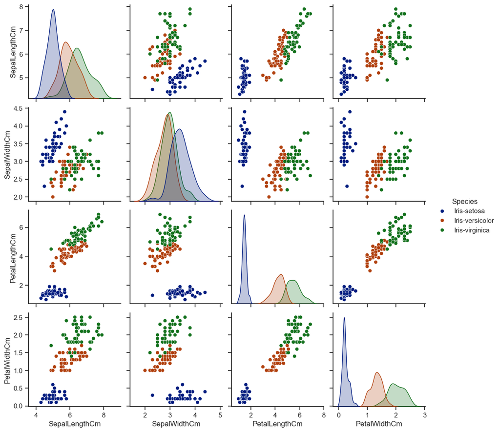

```python
# 1. Clean feature column names (optional, but keeps things neat)
#df.columns = [c.replace(" (cm)", "").replace(" ", "_") for c in df.columns]
df_features = df.drop(columns=["Id"])

# 2. Set style and plot a comprehensive pairplot matrix
sns.set_theme(style="ticks")
pair_plot = sns.pairplot(df_features, hue="Species", palette="dark")

# 3. Save the figure
pair_plot.savefig("features_by_species.png", bbox_inches="tight")
plt.show()
```

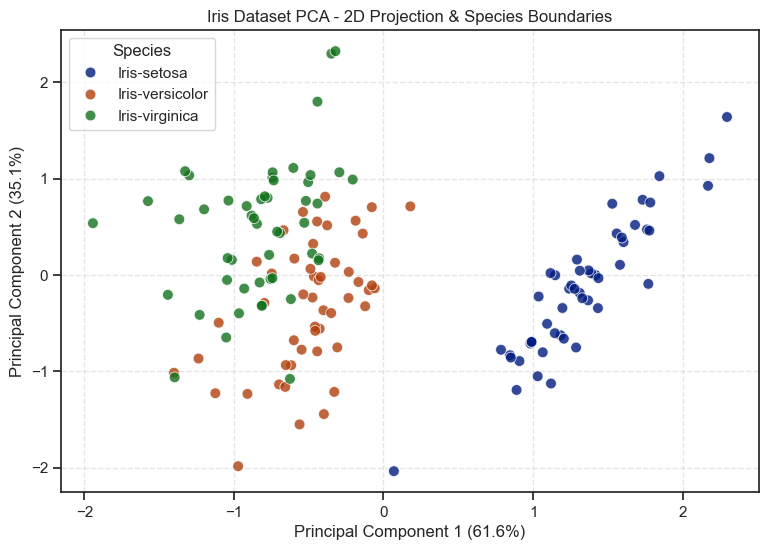

```python
from sklearn.decomposition import PCA
from sklearn.preprocessing import RobustScaler

# 1. Separate features from the target species (using your df_features from earlier)
# Make sure to only include numeric columns for PCA
X = df_features.drop(columns=["Species"])
y = df_features["Species"]

# 2. PCA is highly sensitive to variances, so standardizing the data is required
X_scaled = RobustScaler().fit_transform(X)

# 3. Apply PCA to project down to 2 dimensions
pca = PCA(n_components=2)
X_pca = pca.fit_transform(X_scaled)

# 4. Create a new DataFrame with the principal components
df_pca = pd.DataFrame(data=X_pca, columns=["PC1", "PC2"])
df_pca["Species"] = y.values

# 5. Plot the 2D representation
plt.figure(figsize=(9, 6))
sns.scatterplot(
    data=df_pca,
    x="PC1",
    y="PC2",
    hue="Species",
    palette="dark",
    alpha=0.8,
    edgecolor="w",
    s=60,
)

# Calculate explained variance to show on the axes
var_exp = pca.explained_variance_ratio_ * 100
plt.xlabel(f"Principal Component 1 ({var_exp[0]:.1f}%)")
plt.ylabel(f"Principal Component 2 ({var_exp[1]:.1f}%)")
plt.title("Iris Dataset PCA - 2D Projection & Species Boundaries")
plt.grid(True, linestyle="--", alpha=0.5)
plt.show()
```

```python
df_pca
```

|  | PC1 | PC2 | Species |
| --- | --- | --- | --- |
| 0 | 1.418234 | -0.002919 | Iris-setosa |
| 1 | 0.845633 | -0.834235 | Iris-setosa |
| 2 | 1.183977 | -0.627141 | Iris-setosa |
| 3 | 1.064347 | -0.804201 | Iris-setosa |
| 4 | 1.580964 | 0.104259 | Iris-setosa |
| ... | ... | ... | ... |
| 145 | -0.865564 | 0.588631 | Iris-virginica |
| 146 | -1.228911 | -0.415372 | Iris-virginica |
| 147 | -0.710733 | 0.448908 | Iris-virginica |
| 148 | -0.205980 | 0.989667 | Iris-virginica |
| 149 | -0.433929 | 0.151547 | Iris-virginica |

150 rows × 3 columns

# Learning Curve and Data Split Strategy

## Data Split Strategy

A machine learning dataset is usually divided into multiple sets:

```
        Full Dataset
             |
-----------------------------
|            |              |
```

Train Validation Test

### 1. Training Set

- Used to train the model.
- Model learns patterns from this data.
- Example: learn weights/parameters.

### 2. Validation Set

- Used to compare models and tune parameters.
- Helps choose:
  - model type
  - hyperparameters
  - PCA components
  - feature settings

### 3. Test Set

- Used only at the end.
- Measures final performance on unseen data.
- Should not be used for model selection.

## Cross Validation

Instead of keeping a separate validation set, we can use cross-validation on training data.

Example: 5-fold cross-validation

Dataset:

[A][B][C][D][E]

Round 1: Train: B,C,D,E Validate: A

Round 2: Train: A,C,D,E Validate: B

Round 3: Train: A,B,D,E Validate: C

Round 4: Train: A,B,C,E Validate: D

Round 5: Train: A,B,C,D Validate: E

Final validation score = average of all rounds.

Benefits:

- More reliable performance estimate
- Reduces dependency on one random split

# 3. Learning Curve

A learning curve shows how model performance changes as training data increases.

It trains the model on different dataset sizes: 10% data 20% data 30% data ... 100% data

For each size it measures:

- Training score
- Validation score

Example:

Data Size,Train Accuracy,Validation Accuracy 10%,99%,75% 50%,97%,88% 100%,96%,92%

# 4. Interpreting Learning Curve

## Overfitting

Training Accuracy → High Validation Accuracy → Low

Meaning:

- Model memorizes training data.
- Does not generalize well.

Solutions:

- More training data
- Regularization
- Simpler model

## Underfitting

Training Accuracy → Low Validation Accuracy → Low

Meaning:

- Model is too simple.

Solutions:

- Better features
- More complex model

## Good Fit

Training Accuracy ≈ Validation Accuracy

Meaning:

- Model learns patterns and generalizes well.

# 5. Correct ML Workflow

Raw Dataset | ↓ Split Data | ↓ Train / Validation / Test | ↓ Cross Validation + Learning Curve | ↓ Choose Model + Parameters | ↓ Train Final Model | ↓ Evaluate Once on Test Data

# 6. Important Rules

## Never use test data for tuning

Test data should be the final unseen evaluation.

## Fit preprocessing only on training data

Examples:

- StandardScaler
- PCA
- Feature selection

Correct flow: Training Data | ↓ Fit Scaler | ↓ Fit PCA | ↓ Train Model

Validation/Test Data | ↓ Use same Scaler | ↓ Use same PCA | ↓ Prediction

# 7. Data Split Strategies

## Random Split

Used when data points are independent.

Examples:

- Classification
- Regression
- Tabular data

Example:

Train: 80% Test: 20%

## Time-Based Split

Used when predicting future data.

Examples:

- Stock prediction
- Sales forecasting
- Logs

Correct:

Train: Past data

Test: Future data

Do not randomly mix past and future.

## Group-Based Split

Used when multiple rows belong to the same entity.

Examples:

- Users
- Patients
- Devices

Avoid:

Train: User A record 1

Test: User A record 2

because it causes data leakage.

Correct:

Train: User A,B,C

Test: User D,E

## Stratified Split

Used when classes are imbalanced.

Example:

Normal = 95% Fraud = 5%

Keep the same class ratio in train and test.

# Final Summary

- Training set → learns model parameters
- Validation set → selects model and tuning
- Test set → final evaluation only
- Cross-validation → reliable validation inside training
- Learning curve → checks effect of more data
- PCA/Scaler should be fitted only on training data
- Split strategy depends on the real-world problem

```python
 %pip install torch
```

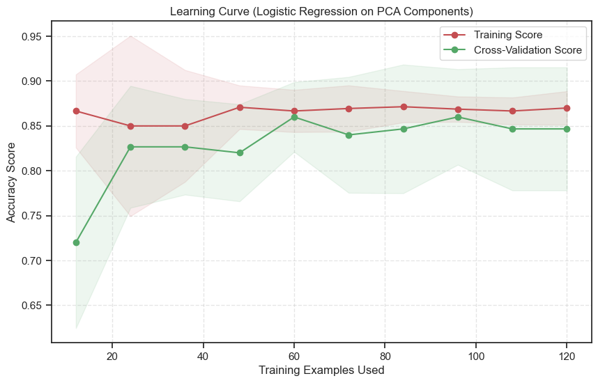

```python
from sklearn.model_selection import learning_curve
from sklearn.linear_model import LogisticRegression

# 1. Define features and target using your PCA dataframe
X_pca_data = df_pca[["PC1", "PC2"]]
y_data = df_pca["Species"]

# 2. Set up the estimator
estimator = LogisticRegression()

# 3. Use the learning_curve function to automatically split, train, and score
train_sizes, train_scores, test_scores = learning_curve(
    estimator,
    X_pca_data,
    y_data,
    cv=5,                             # 5-fold cross-validation splits
    scoring="accuracy",
    train_sizes=np.linspace(0.1, 1.0, 10), # Test 10 different training set sizes
    shuffle=True,                     # <--- FIXES THE ONE-CLASS ERROR
    random_state=42,                  # <--- Keeps the random shuffle consistent
    n_jobs=-1,
)

# 4. Calculate mean and standard deviation for training and testing scores
train_mean = np.mean(train_scores, axis=1)
train_std = np.std(train_scores, axis=1)
test_mean = np.mean(test_scores, axis=1)
test_std = np.std(test_scores, axis=1)

# 5. Plot the learning curve
plt.figure(figsize=(10, 6))

# Plot training accuracy
plt.plot(train_sizes, train_mean, "o-", color="r", label="Training Score")
plt.fill_between(
    train_sizes, train_mean - train_std, train_mean + train_std, alpha=0.1, color="r"
)

# Plot cross-validation (testing) accuracy
plt.plot(
    train_sizes, test_mean, "o-", color="g", label="Cross-Validation Score"
)
plt.fill_between(
    train_sizes, test_mean - test_std, test_mean + test_std, alpha=0.1, color="g"
)

plt.title("Learning Curve (Logistic Regression on PCA Components)")
plt.xlabel("Training Examples Used")
plt.ylabel("Accuracy Score")
plt.legend(loc="best")
plt.grid(True, linestyle="--", alpha=0.5)
plt.show()
```

```python
%pip install xgboost
```

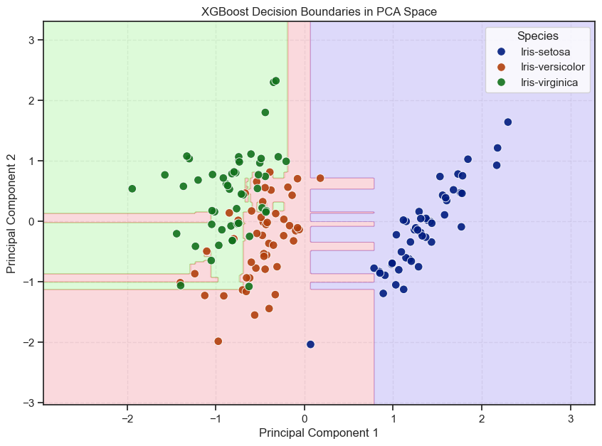

```
XGBoost Training Accuracy on PCA components: 94.67%
```

```python
import matplotlib.pyplot as plt
import numpy as np
import pandas as pd
import seaborn as sns
from sklearn.preprocessing import LabelEncoder
from xgboost import XGBClassifier

# 1. Encode target string labels into integers (0, 1, 2)
le = LabelEncoder()
y_encoded = le.fit_transform(df_pca["Species"])
X_pca_data = df_pca[["PC1", "PC2"]].values

xgb_model = XGBClassifier(
    eval_metric="mlogloss",
    max_depth=3,          # Limit how deep each tree can grow (prevents micro-managing data)
    learning_rate=0.05,    # Slow down learning so it doesn't over-adjust to noise
    n_estimators=50,      # Reduce the total number of trees
    subsample=0.8,         # Train on a random 80% of rows per tree to add randomness
    colsample_bytree=0.8   # Train on a random 80% of features per tree
)
xgb_model.fit(X_pca_data, y_encoded)

# 3. Create a mesh grid to plot the decision boundary areas
x_min, x_max = X_pca_data[:, 0].min() - 1, X_pca_data[:, 0].max() + 1
y_min, y_max = X_pca_data[:, 1].min() - 1, X_pca_data[:, 1].max() + 1
xx, yy = np.meshgrid(np.arange(x_min, x_max, 0.02), np.arange(y_min, y_max, 0.02))

# 4. Predict the class for each point on the grid
grid_points = np.c_[xx.ravel(), yy.ravel()]
Z = xgb_model.predict(grid_points)
Z = Z.reshape(xx.shape)

# 5. Plot the background decision regions
plt.figure(figsize=(10, 7))
plt.contourf(xx, yy, Z, alpha=0.15, cmap=plt.cm.brg)

# Overlay the original scatter data points
sns.scatterplot(
    data=df_pca,
    x="PC1",
    y="PC2",
    hue="Species",
    palette="dark",
    alpha=0.9,
    edgecolor="w",
    s=70,
)

plt.xlabel("Principal Component 1")
plt.ylabel("Principal Component 2")
plt.title("XGBoost Decision Boundaries in PCA Space")
plt.grid(True, linestyle="--", alpha=0.3)
plt.show()

# 6. Print Model Accuracy
accuracy = xgb_model.score(X_pca_data, y_encoded) * 100
print(f"XGBoost Training Accuracy on PCA components: {accuracy:.2f}%")
```